# Useful inspection plots for the MotU

# Backlog and Notes

2022-12-15: **NOTE** this is a messy file, use the Outline to navigate quickly!

2022-12-15: **TODO** make copies for pacman did/caf -> might need further tweaking because some metadata is different.

2022-12-16: **TODO** once this file is cleaned up and to your liking, include it in the targets pipeline so it auto-updates? https://books.ropensci.org/targets/literate-programming.html

2022-12-20: **NOTE** I’ve now cleaned this up a bit, it looks at everything since 2021.

2023-01-19: **NOTE** Updated pacman workflow, should include pacman inspection plots here or in a separate file?

Once you have run the code, we can inspect the output!

# Libraries

This loads the libraries + plotting helpers (sam = scale_alpha_manual for outliers).

```r
source("R/libraries.R")

  # Loads globals like tar_option_set() packages and functions
#  library(targets)
#  tar_load_globals()
```

# Interactive Plots

If there is ever a plot you’d like to zoom in on, make an interactive version of it with this `ggp()` function.

Note that it sets the axis titles to blank, because plotly cannot handle formula axis labels and we use those a lot (e.g. ylab = delta^{18}*O~“(VPDB 030)”).

```r
  ggp <- function(pl = ggplot2::last_plot(), h = NULL) {
     # convert to WebGL for speed -> doesn't work in RStudio browser
 #plotly::toWebGL(
    plotly::ggplotly(
   # select the last ggplot object
   # you can also replace that with an object that holds the plot
      p = pl +
        # disable the axis titles (needed in case you have formulae for the axes)
        theme(axis.title.x = element_blank(),
              axis.title.y = element_blank()),
      # make new tickmarks show up when you zoom in/out
      dynamicTicks = TRUE, height = h)
    #)
  }
```

# Custom Filters

These are used to zoom in on only the measurements you want to see!

Currently it focuses on all measurements since 2021. The last manual outlier was marked in November 2021.

```r
  scan_filter <- function(data) {
    data |>
      filter(scan_datetime > lubridate::ymd("2021-01-01"))
  }

  measurement_filter <- function(data) {
    data |>
      filter(file_datetime > lubridate::ymd("2021-01-01"))
  }
```

# Background Scans

## Raw scans

This is a plot of the raw scans. It takes quite a while to make, so it might be useful to filter first.

[output not shown]

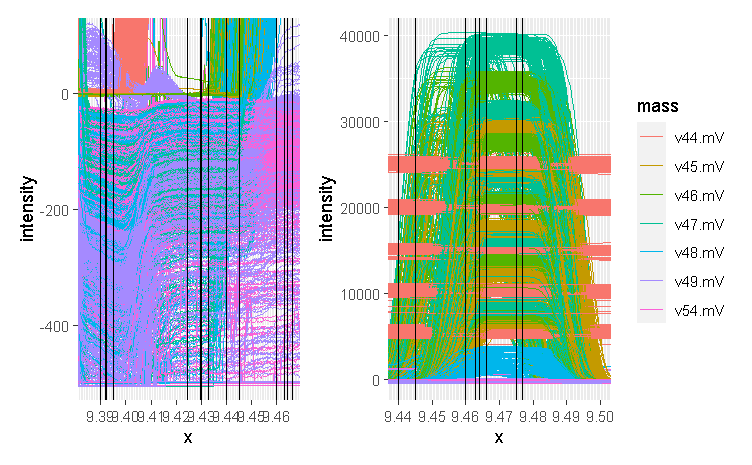

[figure not shown]

```r
# show the minimum and maximum side-by-side
pl_scn + (pl_scn + coord_cartesian(xlim = c(9.44, 9.5),
                                   ylim = c(-500, 4e4))) + # for the maximum
  plot_layout(guides = "collect")
```

## Min/Max vs. Time

```r
tar_read(motu_scn_mod) |>
#tar_read(pacman_scn_mod) |>
  bind_rows() |>
  # filter your range of interest
  scan_filter() |>
  unnest(cols = data) |>
  ggplot(aes(x = scan_datetime,
             label = scan_group,
             colour = factor(voltage),
             file_id = file_id,
             alpha = outlier_scan_manual,
             ##y = min_44
             ## y = min_45
             ## y = min_46
             y = min_47
             ## y = min_48
             ## y = min_49
             ## y = min_54
             ## y = max_44
  )) +
  geom_point() +
  sam
```

```
filter: removed 467 rows (64%), 260 rows remaining
```

## BG Models

It looks like for mass 45 it might make a difference, but then again the y-axis value is only 2 on a scale of 15000 so I’ll just leave it be for now.

```r
wr_minmaxs <- tar_read(motu_scn_mod) |>
  bind_rows() |>
  scan_filter() |>
  unnest(cols = data) |>
  # remove metadata for easier pivoting
  select(-c(min, max, min_start_44, min_end_44,
            min_start_45_49, min_end_45_49,
            max_start, max_end)) |>
  pivot_longer(cols = starts_with("min_"),
               names_to = "min_mass",
               values_to = "minimum") |>
  mutate(mass = str_extract(min_mass, "\\d{2}"))
```

```
filter: removed 467 rows (64%), 260 rows remaining
select: dropped 8 variables (min, max, min_start_44, min_end_44, min_start_45_49, …)
pivot_longer: reorganized (min_44, min_45, min_46, min_47, min_48, …) into (min_mass, minimum) [was 1271x37, now 8897x32]
mutate: new variable 'mass' (character) with 7 unique values and 0% NA
```

```r
wr_minmaxs |>
  ggplot(aes(x = max_44, y = minimum, #colour = mass,
             label = scan_group,
             file_id = file_id)) +
  ## geom_smooth(aes(group = mass), method = "lm", se = F) +
  ## geom_smooth(aes(group = mass), formula = y ~ x - 1, method = "lm", se = F, colour = "orange") +
  ## geom_smooth(aes(group = paste(scan_group, mass), colour = scan_datetime),
  ##             formula = y ~ poly(x, 2, raw = TRUE) - 1,
  ##             method = "lm", se = F, alpha = .2) +
  geom_smooth(aes(group = paste(scan_group, mass),
                  colour = scan_datetime),
              formula = y ~ poly(x, 3, raw = TRUE),
              method = "lm", se = F, alpha = .2,
              data = wr_minmaxs |> filter(!outlier_scan_manual)) +
  geom_point(aes(alpha = outlier_scan_manual, colour = scan_datetime),
             size = 3) +
  sam +
  ## geom_abline(aes(slope = slope, intercept = intercept, colour = scan_datetime),
  ##             data = wr_lines,
  ##             alpha = .1) +
  ## geom_hline(yintercept = -500, colour = "red") +
  facet_wrap(vars(mass), scales = "free_y")
```

```
filter: removed 56 rows (1%), 8,841 rows remaining
```

## Weird Scans

I think by now I’ve adjusted all the ranges to match all the WR scans that had weird slopes before, remainder may be from contamination (e.g. 190619 etc.)

```r
  weird_scans <- c(#"17April2018", # problematic ones
                   ## "22November2017", ## "17April2018", # large shift in x, even after correcting off from remainder
                   ## "190415" # this run has very different ETH-1 and ETH-2, but appears normal here
                   ## this whole period has very weird scans, machine contaminated with corals? continues probably until 2019-07-02
      ## "14March2018", "16March2018", "19March2018", "21March2018", "22March2018", "23March2018"
      ## "17April2018"
      ## "14September2018"
      #"190130"
                   ## "190619"## ,
                   ## "190621",
                   ## "190624",
                   ## "190625",
                   ## "190627",
                   ## "190628", ## between 2020-01-03 and 2020-04-07 there is larger scatter than usual!
                   ## "200213", # not as bad as before anymore after adjusting ranges
                   ## "200302",
                   ## "200831", # is higher than bracketing scans
                   ## "200901", # is higher than bracketing scans
                   ## "200903" # is higher than bracketing scans
                   ## "201216", # fixed after adjusting scan range
                   ## "201223", # maybe a bit low?
                   ## "210104",
                   ## "210107", # fixed after adjusting scan range
                   ## "210114",
                   ## "210115" # a little high but they all are
    "220207",
    "211112"
                   )

  tar_read(motu_scn_fix) |>
    bind_rows() |>
    tidylog::filter(scan_group %in% weird_scans) |>
    pivot_longer(cols = v44.mV:v49.mV,
                 names_to = "mass",
                 values_to="intensity") |>
    ggplot(aes(x = x, y = intensity,
               colour = mass,
               # below aesthetics don't do anything, but assigning them
               # is useful: if you make this plot interactive, all the
               # aesthetics will show up on hovering a point!
               sg = scan_group,
               fi = file_id,
               fd = file_datetime,
               fs = fix_software,
               o = outlier_scan_manual)) +
    geom_line(aes(group = paste(file_id, mass, voltage))) +
    # sam = scale_alpha_manual(...) defined in libraries.R
    sam +
    geom_vline(aes(xintercept = value),
               data = tar_read(motu_scn_mod) |>
                 bind_rows() |>
    filter(scan_group %in% weird_scans) |>
                 unnest(data) |>
                 distinct(min_start_44, min_end_44, min_start_45_49, min_end_45_49, max_start, max_end) |>
                 pivot_longer(cols = c(starts_with("min"), starts_with("max")))) #+
```

```
filter: removed 1,897,791 rows (>99%), 5,251 rows remaining
pivot_longer: reorganized (v44.mV, v45.mV, v46.mV, v47.mV, v54.mV, …) into (mass, intensity) [was 5251x32, now 36757x27]
filter: removed 725 rows (>99%), 2 rows remaining
distinct: removed 9 rows (90%), one row remaining
pivot_longer: reorganized (min_start_44, min_end_44, min_start_45_49, min_end_45_49, max_start, …) into (name, value) [was 1x6, now 6x2]
```

```r
    ## facet_wrap(vars(scan_group))
```

# Inspect the metadata

## Analysis

Are all the files represented in the metadata file?

```r
  mm <- tar_read(motu_metadata) |> bind_rows()
  mi <- tar_read(motu_file_info) |> bind_rows()

  c(analysis = all(mm$Analysis %in% mi$Analysis), file_id = all(mm$file_id %in% mi$file_id))
```

[output not shown]

## file_id

which file_id’s that are in the metadata are not in the file info? These rows need to be deleted from the <sub>motu_metadata_parameters</sub> excel file

```r
  mm |> tidylog::filter(!file_id %in% mi$file_id)
```

```
filter: removed all rows (100%)
```

| Analysis | file_id | file_root | file_subpath | file_path | file_datetime | file_size | Row | Peak Center | Background | Pressadjust | Reference Refill | Line | Sample | Weight [mg] | Identifier 1 | Identifier 2 | Comment | Preparation | Method | ref_mbar | ref_pos | bellow_pos_smp | init_int | background2 | PC | VM1_aftr_trfr | CO2_after_exp | no_exp | total_CO2 | … |
| --- | --- | --- | --- | --- | --- | --- | --- | --- | --- | --- | --- | --- | --- | --- | --- | --- | --- | --- | --- | --- | --- | --- | --- | --- | --- | --- | --- | --- | --- | --- |

## which file_id’s that are in the file info are not in the metadata?

These need to be added to the metadata

```r
  # motu info, filtered for those file_id's that are NOT in motu_metadata
  mi |> tidylog::filter(!file_id %in% mm$file_id | !Analysis %in% mm$Analysis) |>
    # copied from export_metadata
    rename(c("manual_outlier" = "outlier_manual")) |>
       tidylog::select(all_of(c("Analysis",
                                "file_id",
                                "file_root",
                                "file_subpath",
                                "file_path",
                                "file_datetime",
                                "file_size",
                                "Row",
                                "Peak Center",
                                "Background",
                                "Pressadjust",
                                "Reference Refill",
                                "Line",
                                "Sample",
                                "Weight [mg]",
                                "Identifier 1",
                                "Identifier 2",
                                "Comment",
                                "Preparation",
                                "Method",
                                # new columns!
                                "ref_mbar",
                                "ref_pos",
                                "bellow_pos_smp",
                                "init_int",
                                "background",
                                "PC",
                                "VM1_aftr_trfr",
                                "CO2_after_exp",
                                "no_exp",
                                "total_CO2",
                                "p_gases",
                                "p_no_acid",
                                "extra_drops",
                                "leak_rate",
                                "acid_temperature",
                                "MS_integration_time.s",
                                "timeofday",
                                "d13C_PDB_wg",
                                "d18O_PDBCO2_wg",
                                # /new columns
                                "s44_init",
                                "r44_init",
                                # more new parms columns
                                ## "bg_group",
                                "scan_group",
                                "scan_datetime",
                                "scan_files",
                                "scan_n",
                                "bg_fac",
                                "dis_min", "dis_max", "dis_fac", "dis_rel",
                                "init_low", "init_high", "init_diff",
                                "p49_crit",
                                "prop_bad_param49",
                                "prop_bad_cyc",
                                "sd_D47", "sd_d13C", "sd_d18O",
                                "off_D47_min", "off_D47_max", "off_D47_grp", "off_D47_width", "off_D47_stds",
                                "off_d13C_min", "off_d13C_max", "off_d13C_grp", "off_d13C_width", "off_d13C_stds",
                                "off_d18O_min", "off_d18O_max", "off_d18O_grp", "off_d18O_width", "off_d18O_stds",
                                "etf_stds", "etf_width",
                                "acid_fractionation_factor",
                                "temperature_slope", "temperature_intercept",
                                # /parms columns
                                "manual_outlier",
                                "Preparation_overwrite",
                                "Identifier 1_overwrite",
                                "Identifier 2_overwrite",
                                "Weight [mg]_overwrite",
                                "Comment_overwrite",
                                "scan_group_overwrite",
                                "Mineralogy",
                                "checked_by",
                                "checked_date",
                                "checked_comment"))) |>
       writexl::write_xlsx("out/more_motu.xlsx")
```

```
filter: removed 27,297 rows (>99%), 23 rows remaining
select: dropped 10 variables (masspec, preparation, identifier_1, identifier_2, weight, …)
```

## preparation assignment

Did we fix all the run number assignments when they were entered incorrectly? (Often we forgot to update the field in the sequence, but we did update the filenames.)

```r
  tar_read(motu_badruns) |>
  tidylog::left_join(tar_read(motu_metadata) |>
                       select(file_id, Preparation_overwrite))
```

```
           > rows only in x        0
           > rows only in y  (27,223)
           > matched rows         73
           >                 ========
           > rows total           73
```

| file_id | Preparation | file_id_prep | Preparation_overwrite |
| --- | --- | --- | --- |
| 180514_27_Chris_1_ETH-1.did | 26 | 27 | 27 |
| 180620_47_Chris_1_ETH-1.did | 46 | 47 | 47 |
| 180625_50_Chris_1_ETH-1.did | 48 | 50 | 50 |
| 180630_54_NathalieBas_1_Naxos.did | 52 | 54 | 54 |
| 180831_83_Cas_1_ETH-1.did | 84 | 83 | 83 |
| 180907_86_Wuyun_1_ETH-3.did | 85 | 86 | 86 |
| 180914_88_WuyunCas_1_ETH-2.did | 86 | 88 | 88 |
| 180928_94_Ilja_1_ETH-3(1).did | 93 | 94 | 94 |
| 190121_138_RB_1_ETH-3.did | 135 | 138 | 138 |
| 190225_154_JM_IAM_1_ETH-3.did | 153 | 154 | 154 |

[output cut: 63 more lines]

This should be empty if all runs have been assigned correct run numbers

```r
  tar_read(motu_temperature) |>
    group_by(preparation) |>
    ## group_by(Preparation) |>
    mutate(mn = min(file_datetime), mx = max(file_datetime)) |>
    ## filter(mn > mx)
    distinct(preparation, .keep_all = TRUE) |>
    select(file_id, Preparation, preparation, mn, mx) |>
    tidylog::mutate(wrong = mx > lag(mn) | mn < lead(mx)) |>
    ## filter(preparation != Preparation)
    tidylog::filter(wrong) |>
    glimpse()
```

```
mutate (grouped): new variable 'wrong' (logical) with one unique value and 100% NA
filter (grouped): removed all rows (100%)
```

```
Rows: 0
Columns: 6
Groups: preparation [0]
$ file_id     <chr>
$ Preparation <int>
$ preparation <dbl>
$ mn          <dttm>
$ mx          <dttm>
$ wrong       <lgl>
```

```r
    ## tidylog::filter(preparation %in% 85:87) |>
```

# All Raw Cycles

These become slow pretty quickly, adjust your `measurement_filter`!

```
           > rows only in x   177,520
           > rows only in y  ( 27,155)
           > matched rows       5,640
           >                 =========
           > rows total       183,160
```

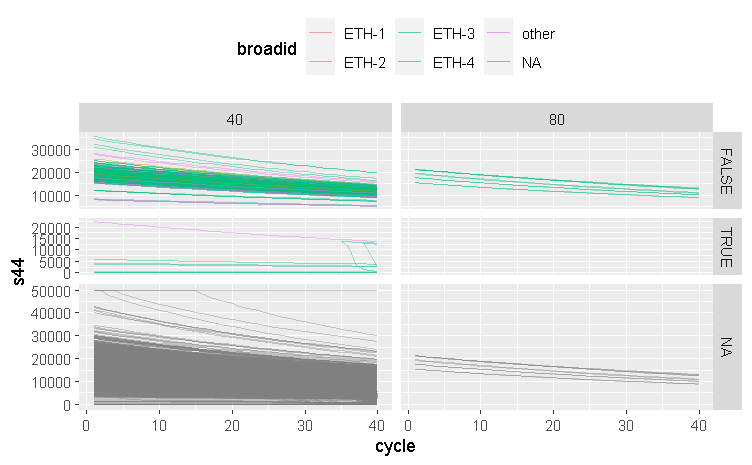

```r
  tar_read(motu_raw_deltas) |>
    bind_rows() |>
    # NOTE: raw delta's doesn't have file_datetime, so need to filter in another way. This is the first measurement in 2022
    filter(Analysis >= 24653L) |>
    add_count(file_id, Analysis) |>
    #mutate(Analysis = parse_double(Analysis)) |>
    select(-scan_files) |>
    rename(cycle_outlier_temp = outlier) |>
    tidylog::left_join(tar_read(motu_temperature) |>
                       bind_rows()) |>
    mutate(out = cycle_outlier_temp | outlier) |>
    ## filter(!cycle_has_drop) |> # i've checked the dropped cycles now, they seem good. This shows the remainder. Did I miss anything?
    ## filter(!cycle_outlier_temp, !outlier) |>
    ## pivot_longer(cols = c(r44:s54, s45_bg:r49_bg), names_to = "mass", values_to = "intensity") |>
    ## glimpse()
    ggplot(aes(x = cycle, group = paste(file_id, Analysis),
               a = Analysis, alpha = out,
               colour = broadid)) +
    ## gghighlight(cycle_has_drop_s44) +
    geom_line(aes(y = s44), alpha = .4) +
    ## gghighlight(cycle_has_drop_r44) +
    geom_line(aes(y = r44), alpha = .4) +
    sam +
    facet_grid(cols = vars(n), rows = vars(out),
               scales = "free", space = "free") + theme(legend.pos = "top")
```

## initial intensity outliers

```
filter: removed 18,645 rows (68%), 8,651 rows remaining
filter: removed 18,645 rows (68%), 8,651 rows remaining
filter: no rows removed
filter: removed 18,645 rows (68%), 8,651 rows remaining
distinct: removed 8,650 rows (>99%), one row remaining
```

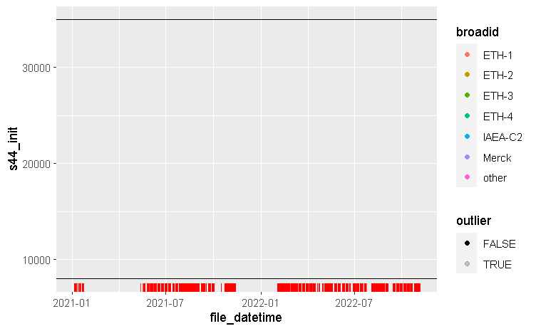

```r
  tar_read(motu_temperature) |>
    measurement_filter() |>
    ggplot(aes(x = file_datetime, y = s44_init,#init_int,
               colour = broadid, alpha = outlier,
               a = Analysis, fi = file_id,
               ro = reason_for_outlier)) +
    sam +
    geom_point() +
    geom_rug(aes(y = NULL),
             data = tar_read(motu_temperature) |>
               measurement_filter() |>
               filter(is.na(s44_init)),
             colour = "red", show.legend = FALSE) +
    geom_hline(yintercept = tar_read(motu_temperature) |>
                 measurement_filter() |>
                 distinct(init_low, init_high) |> unlist())
```

### difference in initial intensity outliers

```
filter: removed 18,645 rows (68%), 8,651 rows remaining
distinct: removed 27,295 rows (>99%), one row remaining
```

[figure not shown]

```r
  tar_read(motu_temperature) |>
    ## filter(file_id %in% wr_ss$file_id) |>
    measurement_filter() |> # the whole range for Robin van der Ploeg's MECO runs
    ggplot(aes(x = file_datetime, y = s44_init - r44_init, colour = broadid, alpha = outlier,
               a = Analysis, fi = file_id, ro = reason_for_outlier)) +
    sam +
    geom_point() +
    # here I plot it as the diff, but in the calculations I use abs(s44 - r44)
    geom_hline(yintercept = tar_read(motu_temperature) |>
                 distinct(init_diff) |> unlist() * c(-1, 1)) +
    coord_cartesian(ylim = c(-3000, 3000))
```

# Measurement Info

Plot all the stuff from IsoDat.

## acid temperature

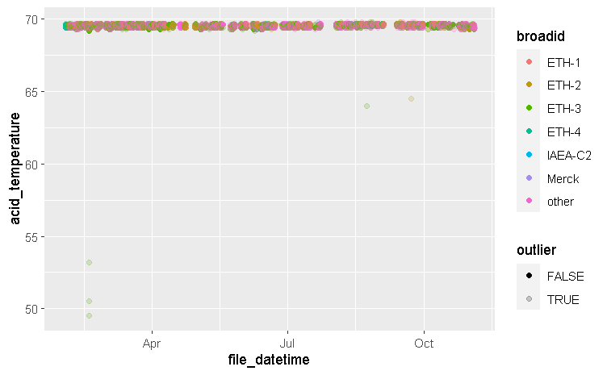

```r
  tar_read(motu_temperature) |>
    measurement_filter() |>
    ggplot(aes(x = file_datetime, y = acid_temperature, colour = broadid, alpha = outlier,
               a = Analysis, fi = file_id, ro = reason_for_outlier)) +
    geom_point() +
    sam
```

```r
    ## coord_cartesian(xlim = as.POSIXct(c(ymd("2021-05-10"), today())), ylim = c(65, NA))
```

## ref_mbar

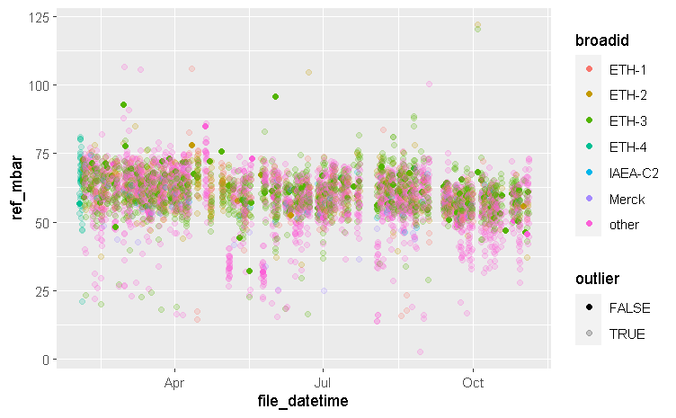

```r
  tar_read(motu_temperature) |>
    measurement_filter() |>
    ggplot(aes(x = file_datetime, y = ref_mbar, colour = broadid, alpha = outlier,
               a = Analysis, fi = file_id, ro = reason_for_outlier)) +
    geom_point() +
    sam
```

## ref_pos

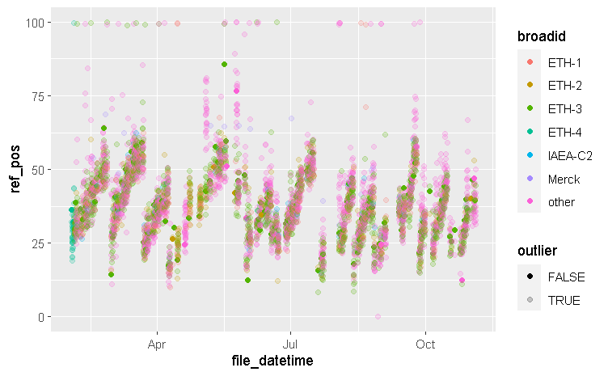

```r
  tar_read(motu_temperature) |>
    measurement_filter() |>
    ggplot(aes(x = file_datetime, y = ref_pos, colour = broadid, alpha = outlier,
               a = Analysis, fi = file_id, ro = reason_for_outlier)) +
    geom_point() +
    sam
```

```r
    ## coord_cartesian(xlim = as.POSIXct(c(ymd("2021-05-10"), today())), ylim = c(65, NA))
```

## bellow_pos_smp always 100

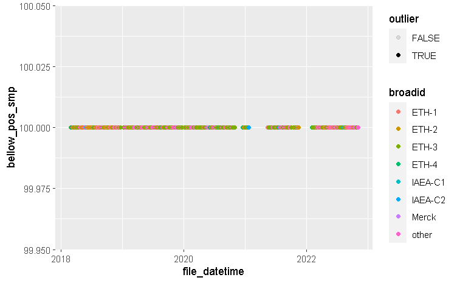

```r
  tar_read(motu_temperature) |>
    ggplot(aes(x = file_datetime, y = bellow_pos_smp, colour = broadid, alpha = outlier,
               a = Analysis, fi = file_id, ro = reason_for_outlier)) +
    geom_point() #+
```

```r
    ## coord_cartesian(xlim = as.POSIXct(c(ymd("2021-05-10"), today())), ylim = c(65, NA))
```

## init_int : not more informative than s44_init or r44_init

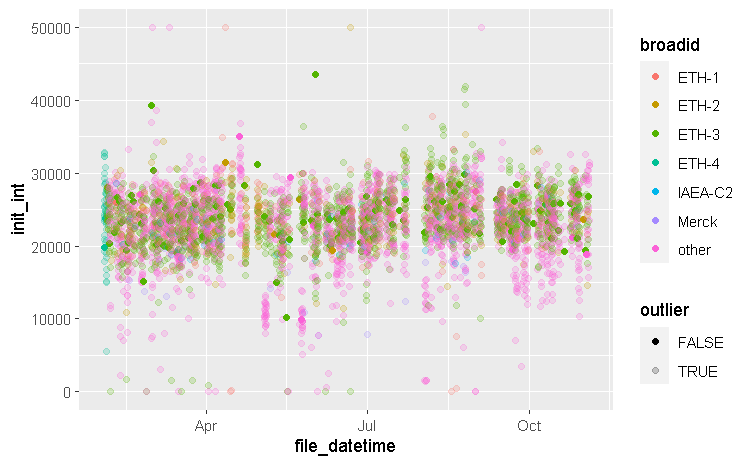

```r
  tar_read(motu_temperature) |>
    measurement_filter() |>
    ggplot(aes(x = file_datetime, y = init_int, colour = broadid, alpha = outlier,
               a = Analysis, fi = file_id, ro = reason_for_outlier)) +
    geom_point() +
    sam
```

```r
    ## coord_cartesian(xlim = as.POSIXct(c(ymd("2021-05-10"), today())), ylim = c(65, NA))
```

## background always NA

[figure not shown]

```r
  tar_read(motu_temperature) |>
    ggplot(aes(x = file_datetime, y = background, colour = broadid, alpha = outlier,
               a = Analysis, fi = file_id, ro = reason_for_outlier)) +
    geom_point() #+
```

```r
    ## coord_cartesian(xlim = as.POSIXct(c(ymd("2021-05-10"), today())), ylim = c(65, NA))
```

## PC : peak centre

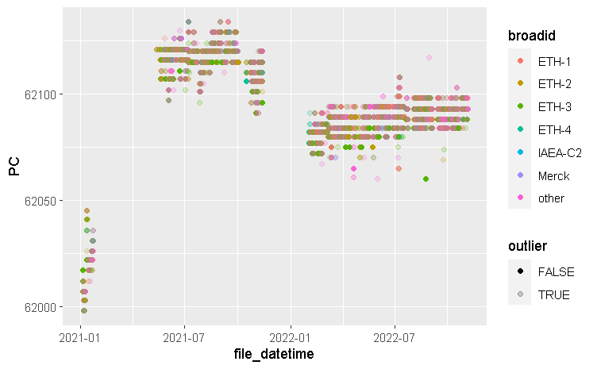

```r
  tar_read(motu_temperature) |>
    measurement_filter() |>
    ggplot(aes(x = file_datetime, y = PC, colour = broadid, alpha = outlier,
               a = Analysis, fi = file_id, ro = reason_for_outlier)) +
    geom_point() +
    sam
```

```r
    ## coord_cartesian(xlim = as.POSIXct(c(ymd("2021-05-10"), today())), ylim = c(65, NA))
```

this peak center PC is the same as the `step` in the scan data! So we can see where it does the peak centering in the scans for comparison. Seems like it might be a bit too much to the right for the latest measurements?

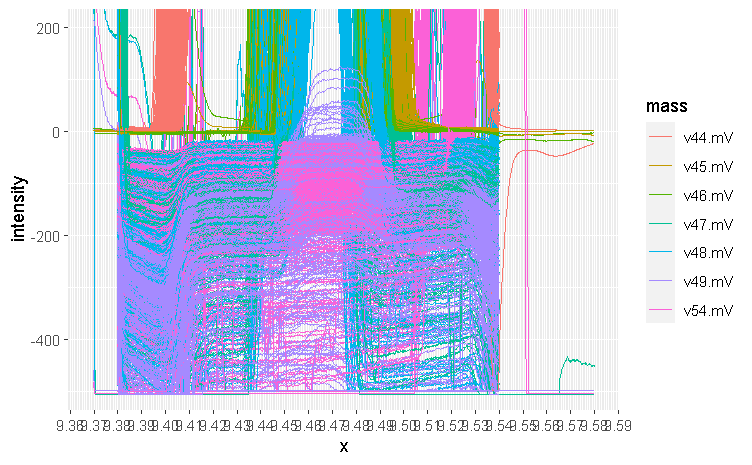

```r
tar_read(motu_scn_fix) |>
  bind_rows() |>
  scan_filter() |>
  pivot_longer(v44.mV:v49.mV, names_to = "mass", values_to = "intensity") |>
  ggplot(aes(x = x, y = intensity, colour = mass)) +
  geom_line(aes(group = paste(file_id, voltage, mass))) +
  #geom_vline(xintercept = c(9.392386, 9.39527, 9.424277, 9.429723, 9.463, 9.466)) +
  scale_x_continuous(breaks = seq(0, 10, 0.01), minor_breaks = seq(0, 10, 0.001)) +
  coord_cartesian(ylim = c(-500, 200))
```

```r
    ## geom_vline(xintercept=c(62100, 62130), colour = "red")  # manually entered the range in the last period
```

make sure that we have set a nice range similar to the PC here

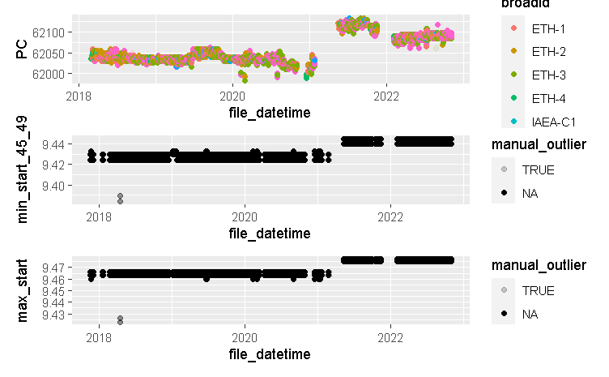

```r
  library(patchwork)
  (tar_read(motu_temperature) |>
    ggplot(aes(x = file_datetime, y = PC, colour = broadid, alpha = outlier,
               a = Analysis, fi = file_id, ro = reason_for_outlier)) +
    geom_point()) /
  (ggplot(tar_read(motu_scn_meta), aes(x = file_datetime, y = min_start_45_49, alpha = manual_outlier, label = scan_group)) + geom_point() + geom_point(aes(y = min_end_45_49))) /
  (ggplot(tar_read(motu_scn_meta), aes(x = file_datetime, y = max_start, alpha = manual_outlier, label = scan_group)) + geom_point() + geom_point(aes(y = max_end)))
```

**** VM1_aftr_trfr

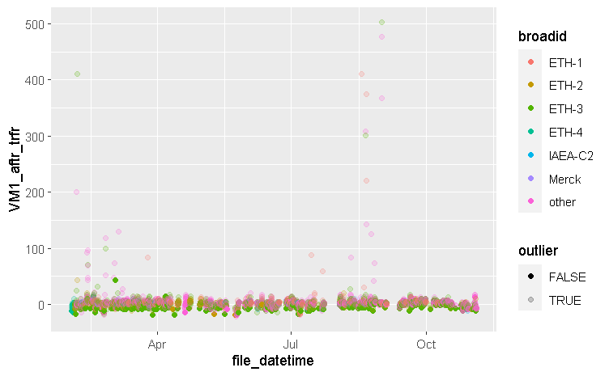

```r
  tar_read(motu_temperature) |>
    measurement_filter() |>
    ggplot(aes(x = file_datetime, y = VM1_aftr_trfr, colour = broadid, alpha = outlier,
               a = Analysis, fi = file_id, ro = reason_for_outlier)) +
    geom_point() +
    sam #+
```

```r
    ## coord_cartesian(xlim = as.POSIXct(c(ymd("2021-05-10"), today())), ylim = c(NA, 200))
```

**** CO2_after_exp

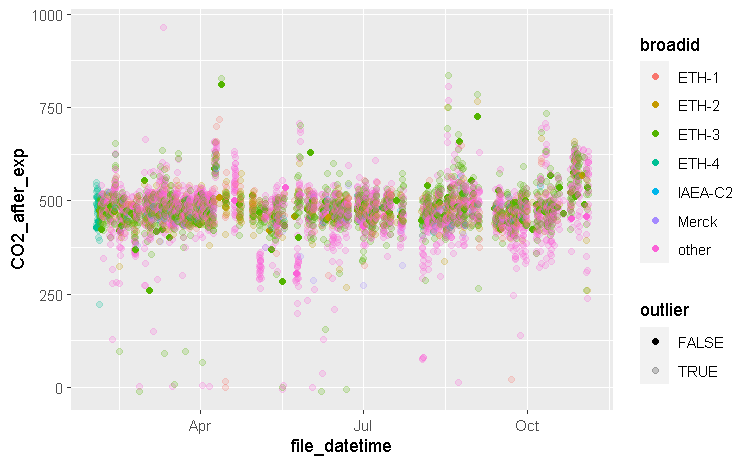

```r
  tar_read(motu_temperature) |>
    measurement_filter() |>
    ggplot(aes(x = file_datetime, y = CO2_after_exp, colour = broadid, alpha = outlier,
               a = Analysis, fi = file_id, ro = reason_for_outlier
               )) +
    geom_point() +
    ## gghighlight(VM1_aftr_trfr > 0) +
    sam
```

```r
    ## coord_cartesian(xlim = as.POSIXct(c(ymd("2021-05-10"), today())), ylim = c(65, NA))
```

**** COMMENT no_exp always 0

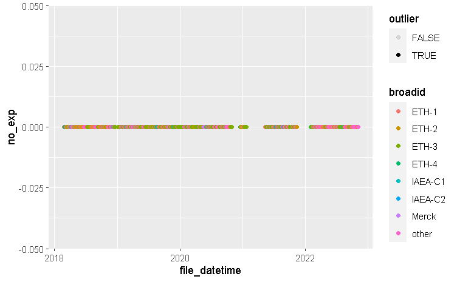

```r
  tar_read(motu_temperature) |>
    ggplot(aes(x = file_datetime, y = no_exp, colour = broadid, alpha = outlier,
               a = Analysis, fi = file_id, ro = reason_for_outlier)) +
    geom_point() #+
```

```r
    ## coord_cartesian(xlim = as.POSIXct(c(ymd("2021-05-10"), today())), ylim = c(65, NA))
```

**** total_CO2

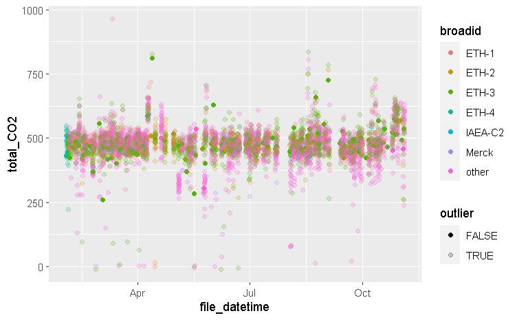

```r
  tar_read(motu_temperature) |>
    measurement_filter() |>
    ggplot(aes(x = file_datetime, y = total_CO2, colour = broadid, alpha = outlier,
               ## a = Analysis, fi = file_id, ro = reason_for_outlier
               )) +
    geom_point() +
    ## gghighlight(VM1_aftr_trfr > 0) +
    sam
```

```r
    ## coord_cartesian(xlim = as.POSIXct(c(ymd("2021-05-10"), today())), ylim = c(65, NA))
```

**** total_CO2 vs initial intensity

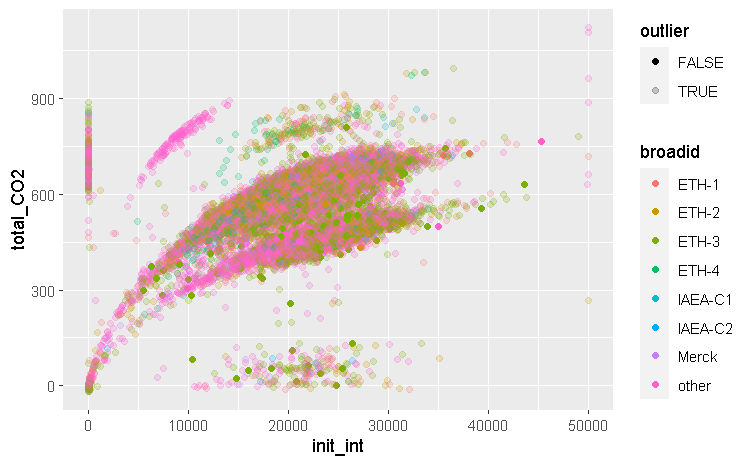

```r
  tar_read(motu_temperature) |>
    #measurement_filter() |>
    ggplot(aes(x = init_int, y = total_CO2, colour = broadid, alpha = outlier,
               a = Analysis, fi = file_id, ro = reason_for_outlier
               )) +
    geom_point() +
    sam #+
```

```r
    #scale_y_log10()
```

**** total_CO2 vs weight

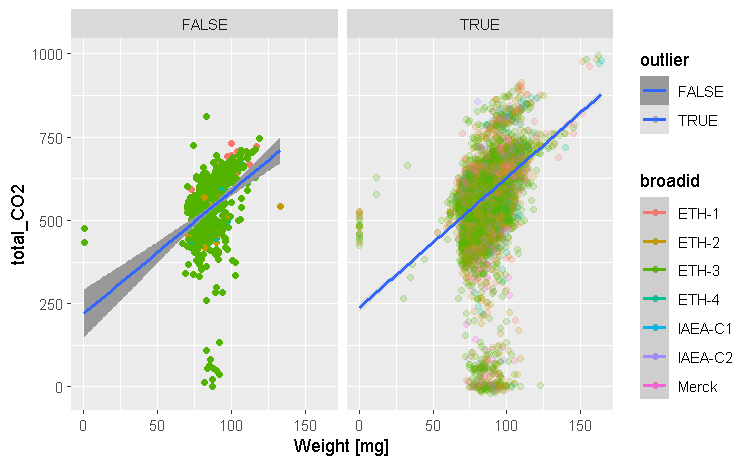

```r
  tar_read(motu_temperature) |>
    #measurement_filter() |>
    filter(broadid != "other") |>
    ggplot(aes(x = `Weight [mg]`, y = total_CO2, colour = broadid## factor(Line)
             , alpha = outlier,
               ## a = Analysis, fi = file_id, ro = reason_for_outlier
               )) +
    geom_point() +
    ## gghighlight(file_datetime > as.POSIXct(ymd("2021-05-10"))) +
    sam +
    facet_grid(cols = vars(outlier)) +
    geom_smooth(aes(group = "all"), method = "lm")
```

```r
    ## coord_cartesian(xlim = as.POSIXct(c(ymd("2021-05-10"), today())), ylim = c(65, NA))
```

**** p_gases

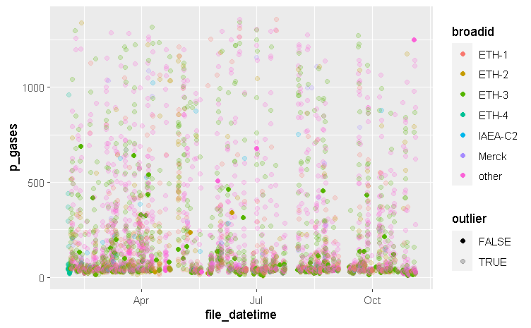

```r
  tar_read(motu_temperature) |>
    measurement_filter() |>
    ggplot(aes(x = file_datetime, y = p_gases, colour = broadid, alpha = outlier,
               a = Analysis, fi = file_id, ro = reason_for_outlier)) +
    geom_point() +
    sam
```

```r
    ## coord_cartesian(xlim = as.POSIXct(c(ymd("2021-05-10"), today())), ylim = c(65, NA))
```

**** p_no_acid

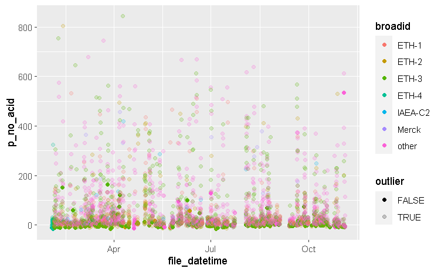

```r
  tar_read(motu_temperature) |>
    measurement_filter() |>
    ggplot(aes(x = file_datetime, y = p_no_acid, colour = broadid, alpha = outlier,
               a = Analysis, fi = file_id, ro = reason_for_outlier)) +
    geom_point() +
    sam
```

```r
    ## coord_cartesian(xlim = as.POSIXct(c(ymd("2021-05-10"), today())), ylim = c(65, NA))
```

**** extra_drops

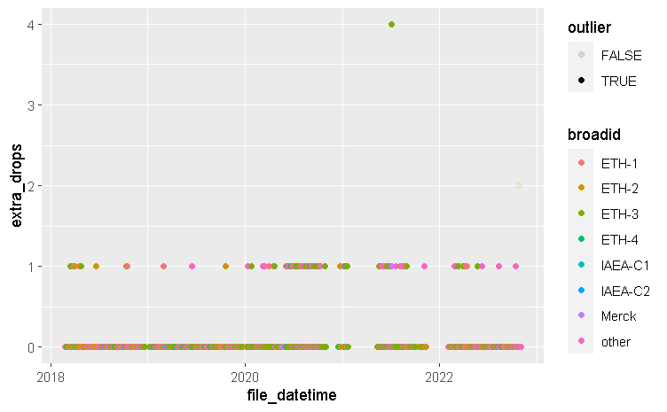

```r
  tar_read(motu_temperature) |>
    ggplot(aes(x = file_datetime, y = extra_drops, colour = broadid, alpha = outlier,
               a = Analysis, fi = file_id, ro = reason_for_outlier)) +
    geom_point() #+
```

```r
    ## coord_cartesian(xlim = as.POSIXct(c(ymd("2021-05-10"), today())), ylim = c(65, NA))
```

**** leak rates

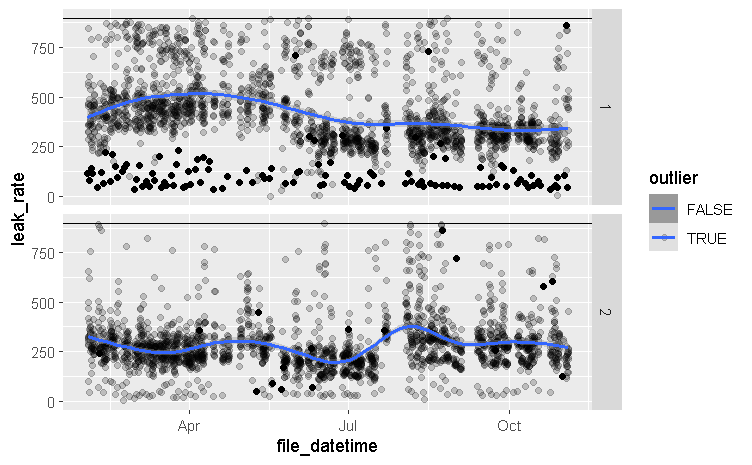

```r
  tar_read(motu_temperature) |>
    measurement_filter() |>
    ggplot(aes(x = file_datetime, y = leak_rate, ## colour = Row,
               alpha = outlier,
               a = Analysis, fi = file_id, ro = reason_for_outlier)) +
    geom_point() +
    geom_hline(yintercept = 900) + # I think this is when it cancels the sample/stops the run?
    geom_smooth(aes(group = Line)) +
    sam +
    facet_grid(rows = vars(Line))
```

**** MS_integration_time.s

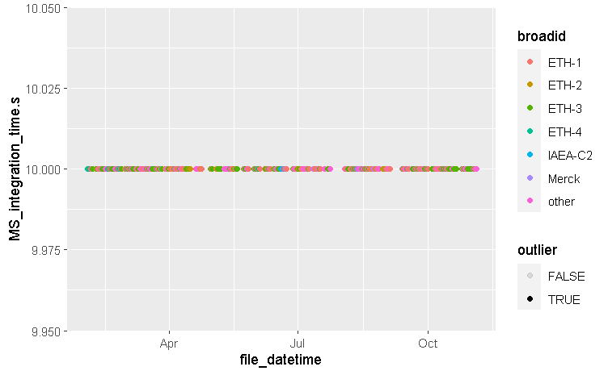

```r
  tar_read(motu_temperature) |>
    measurement_filter() |>
    ggplot(aes(x = file_datetime, y = MS_integration_time.s, colour = broadid, alpha = outlier,
               a = Analysis, fi = file_id, ro = reason_for_outlier)) +
    geom_point() #+
```

```r
    ## coord_cartesian(xlim = as.POSIXct(c(ymd("2021-05-10"), today())), ylim = c(65, NA))
```

# Raw Data

## raw D47

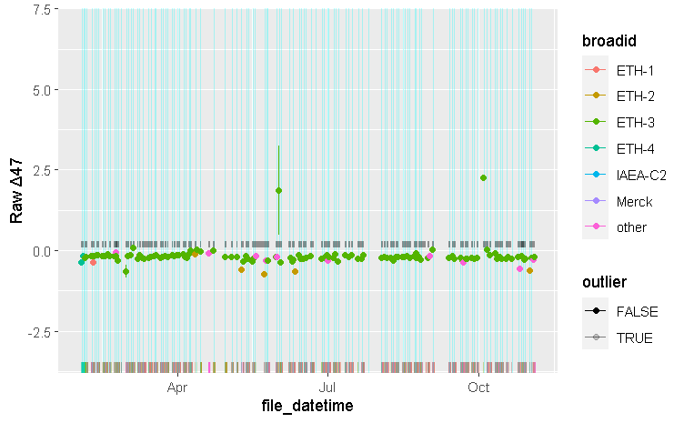

```r
  pl_D47raw <- tar_read(motu_temperature) |>
    measurement_filter() |>

    arrange(file_id, Analysis, file_datetime) |>

    ggplot(aes(x=file_datetime,
               y=D47_raw_mean,
               ## shape = outlier_param49,
               ymin=D47_raw_mean-D47_raw_sd,
               ymax=D47_raw_mean+D47_raw_sd,
               col=broadid,
               file_id = file_id,
               Analysis = Analysis,
               preparation = preparation,
               sg = scan_group,
               reason_for_outlier = reason_for_outlier,
               alpha=outlier)) +

     ## # annotate logbook issues etc.
     ## geom_vline(aes(xintercept = datetime,
     ##                n = Name,
     ##                p = `Samples (Name, material, #)`,
     ##                label = `Comments (issues, observations, maintenance):`),
     ##            data = tar_read(motu_log), alpha = .2, colour = "gray3") +
     ## geom_text(aes(x = datetime, y = .2, label = Name),
     ##           hjust = 0, size = 3,
     ##           inherit.aes = FALSE,
     ##           data = tar_read(motu_log), alpha = .2, colour = "gray3") +
     ## geom_vline(aes(xintercept = Date,
     ##                n = Name,
     ##                p = `Problem (issues, observations):`,
     ##                a = Actions),
     ##            data = tar_read(motu_maintenance)) +
     ## geom_pointrange() +

     # annotate measurements that didn't get a D47_raw_mean value
     geom_rug(sides = "b", data = ## wr_ss
              tar_read(motu_temperature) |>
                filter(is.na(D47_raw_mean)) |>
                measurement_filter()
              ) + # annotate failed measurements

    # vertical lines for each scan start
    geom_vline(aes(xintercept = scan_datetime, sg = scan_group, bgg = bg_group),
               colour = "cyan", alpha = .3,
               data = tar_read(motu_temperature) |>
                 measurement_filter() |>
                 distinct(scan_datetime, .keep_all = TRUE)
               ) +

    # segments for each preparation (is nicest for interactive graph)
    geom_segment(aes(x = mn, xend = mx, y = 0.2, yend = 0.2, prep = preparation),
                 alpha = .4, size = 2,
                 inherit.aes = FALSE,
                 data = tar_read(motu_temperature) |>
                 measurement_filter() |>
                   group_by(preparation) |>
                   summarize(mn = min(file_datetime), mx = max(file_datetime))
                 ) +

     # the data itself
     geom_errorbar(aes(ymin = D47_raw_lwr, ymax = D47_raw_upr)) +
     geom_point() +
     geom_line(aes(group = broadid)) +

     # customize the plot legends etc.
     scale_alpha_manual(values=c("TRUE" = 0.2, "FALSE" = 1)) +
     labs(y = "Raw Δ47") +
     coord_cartesian(## xlim = c(
                     ##  ## as.POSIXct(ymd("2020-12-17")),
                     ##  as.POSIXct(ymd("2018-02-23")),
                     ##  ## as.POSIXct(today())
                     ##  ## as.POSIXct(today() - months(3)),
                     ##  ## as.POSIXct(today() - weeks(2)),
                     ##  ## as.POSIXct(today() - days(10)),
                     ##  NA
                     ## ),
      # ylim = c(-.7, .2)
     )
  pl_D47raw
```

I’ve added logbook and maintenance notes (commented out now), this makes this full-view figure very useless, but this is great for the interactive version of the plot.

## raw D48

[figure not shown]

```r
  pl_D48raw <- tar_read(motu_temperature) |>
    measurement_filter() |>
    filter(!outlier, broadid == "IAEA-C2", # file_datetime > as.POSIXct("2021-04-01")
           ) |>
    arrange(file_id, Analysis, file_datetime) |>
    ggplot(aes(x=file_datetime,
               y=D48_raw_mean,
               ## shape = outlier_param49,
               ymin=D48_raw_mean-D48_raw_sd,
               ymax=D48_raw_mean+D48_raw_sd,
               col=broadid,
               file_id = file_id,
               Analysis = Analysis,
               preparation = preparation,
               sg = scan_group,
               reason_for_outlier = reason_for_outlier,
               alpha=outlier)) +
     ## geom_vline(aes(xintercept = datetime,
     ##                n = Name,
     ##                p = `Samples (Name, material, #)`,
     ##                label = `Comments (issues, observations, maintenance):`),
     ##            data = tar_read(motu_log), alpha = .2, colour = "gray3") +
     ## geom_text(aes(x = datetime, y = .2, label = Name),
     ##           hjust = 0, size = 3,
     ##           inherit.aes = FALSE,
     ##           data = tar_read(motu_log), alpha = .2, colour = "gray3") +
     ## geom_vline(aes(xintercept = Date,
     ##                n = Name,
     ##                p = `Problem (issues, observations):`,
     ##                a = Actions),
     ##            data = tar_read(motu_maintenance)) +
     ## geom_pointrange() +
     ## geom_rug(sides = "b", data = ## wr_ss
     ##          tar_read(motu_temperature) |> filter(is.na(D47_raw_mean))
     ##          ) +
    # annotate failed measurements
     geom_point() +
     geom_line(aes(group = broadid)) +
     ## gghighlight(.data$file_id %in% wr_ss$file_id) +
     scale_alpha_manual(values=c("TRUE" = 0.2, "FALSE" = 1)) +
     labs(y = "Raw Δ48") +
     geom_hline(yintercept = c(-1, 1))
  pl_D48raw
```

# Background Factors

## what are the bg factors?

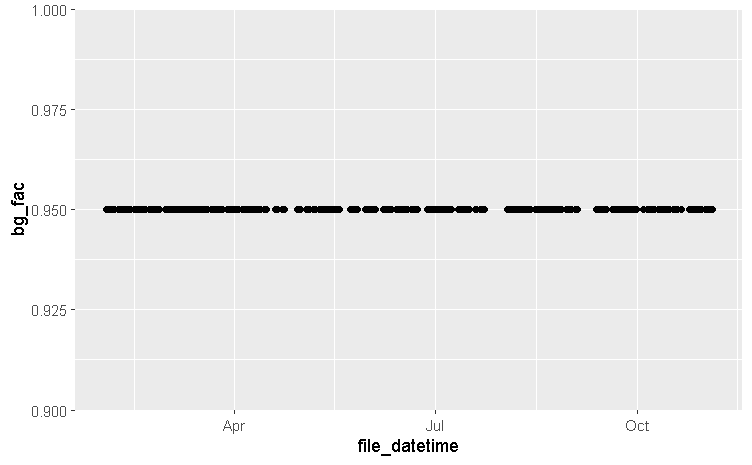

```r
  tar_read(motu_metadata) |>
    measurement_filter() |>
   ggplot(aes(x = file_datetime, y = bg_fac, fi = file_id, a = Analysis)) +
   geom_point() #+
```

```r
   ## coord_cartesian(ylim = c(0, 1))
```

## background factors from final averages

We can calculate this already at the raw_cycle level so that we do not have to do unnecessary computations for bad bg factors.

This does mean we have to redo some simple house-keeping, i.e. getting ETH-1 and ETH-2 filtered out somehow.

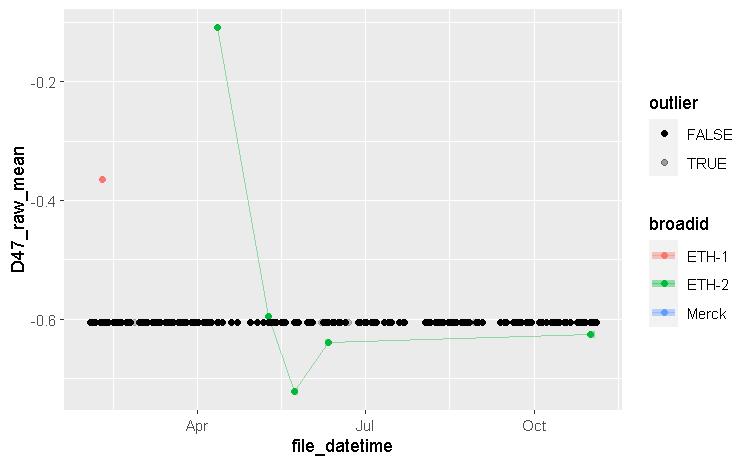

```r
  pl_bgc <- tar_read(motu_temperature) |>
    measurement_filter() |>
    filter(broadid %in% c("ETH-1", "ETH-2", "Merck")) |>
    # cut up into monthly/yearly slices and tweak factor accordingly?
    ggplot(aes(x = file_datetime, y = D47_raw_mean,
               colour = broadid, alpha = outlier, #label = reason_for_outlier,
               fi = file_id, A = Analysis,
               s4 = s44_init, r4 = r44_init,
               p49 = param_49_mean, p = preparation)) +
    geom_point() +
    sam +
    ## # a simple loess fit
    ## geom_smooth(aes(linetype = outlier, group = broadid), method = "loess", se = F, span = .1,
    ##             data = tar_read(motu_temperature) |>
    ##               filter(!outlier, broadid %in% c("ETH-1", "ETH-2"))) +
    ## # a weekly average line
    ## stat_summary(aes(x = summ, group = broadid), geom = "line",
    ##              alpha = .4, size = 2,
    ##              data = tar_read(motu_temperature) |>
    ##                filter(# Analysis %in% wr_ss$Analysis,
    ##                  broadid %in% c("ETH-1", "ETH-2"), !outlier) |>
    ##                mutate(summ = lubridate::floor_date(file_datetime, "week"))
    ##              ) +
    # a line through all the preparation averages
    stat_summary(aes(x = summ, group = broadid), geom = "line",
                 alpha = .4, #size = 2,
                 data = tar_read(motu_temperature) |>
                   measurement_filter() |>
                   filter(# Analysis %in% wr_ss$Analysis,
                     broadid %in% c("ETH-1", "ETH-2"), !outlier) |>
                   group_by(preparation) |>
                   mutate(summ = mean(file_datetime))
                 ) +
    # segments for each preparation (is nicest for interactive graph)
    stat_summary(aes(x = mn, xend = mx, group = broadid), geom = "segment",
                 alpha = .4, size = 2,
                 fun.data = ~ data.frame(y = mean(.x, na.rm = TRUE), yend = mean(.x, na.rm = TRUE)),
                 data = tar_read(motu_temperature) |>
                   measurement_filter() |>
                   group_by(preparation) |>
                   mutate(summ = mean(file_datetime), mn = min(file_datetime), mx = max(file_datetime)) |>
                   filter(# Analysis %in% wr_ss$Analysis,
                     broadid %in% c("ETH-1", "ETH-2"), !outlier)
                 ) +
  geom_point(aes(y = bg_fac / 10 - .7), colour = "black",
             data = tar_read(motu_temperature) |>
                 measurement_filter()) #+
    #coord_cartesian(ylim = c(-.74, -.07))
  pl_bgc
```

for the interval between 2020-01 and 2020-11 I’ve first tried changing the bg factor from: - 0.9 (default for rest) - 1.0 seems to make it a lot better! - 0.7 made them move very far apart

this is quite slow to calculate so I only tried a few. Note that perhaps the BG fac should be changed to 1 also for the most recent runs!

for the one interval that’s acting up weird (end of 2019) we currently tried: bg factor (sorted by factor in the end) - 0.7 ETH-2 is lower than ETH-1 - 0.8: ETH-2 is lower than ETH-1, farther apart. - 0.85: ETH-2 is still lower than ETH-1, but they’re much closer - 0.9 (default) ETH-1 is XXX than ETH-2 (forgot :O) - 0.91 (so that I can still search and replace if I need to change these values): now they’re great, but they cross near 5402 - 0.99 ETH-1 is lower than ETH-2, but closer. So perhaps I just overshot it with 0.7?

then I tweaked some more parts where it seemed obvious that for several runs one of the two was higher/lower than the other.

**** did these issues get fixed in final values?

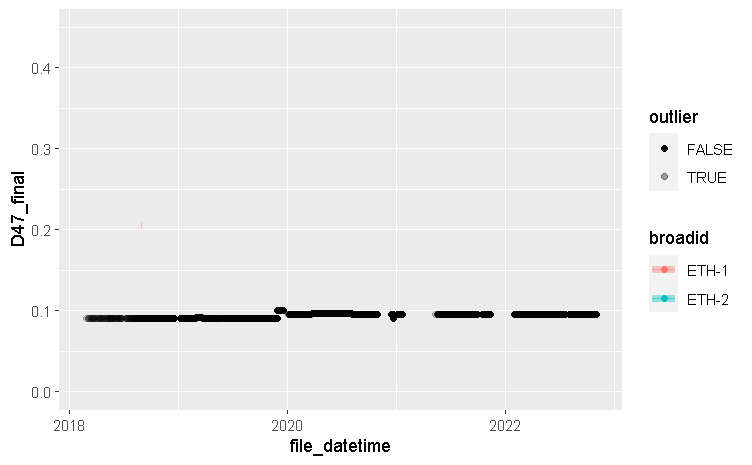

```r
  ## pl_bgc <- #wr_raw_ss |>
   library(patchwork)
    tar_read(motu_temperature) |>
    measurement_filter() |>
    filter(## Analysis %in% wr_ss$Analysis,
           broadid %in% c("ETH-1", "ETH-2")) |>
    ggplot(aes(x = file_datetime, y = D47_final, colour = broadid, alpha = outlier, label = reason_for_outlier,
               fi = file_id, A = Analysis, s4 = s44_init, r4 = r44_init, p49 = param_49_mean, f = bg_fac)) +
  geom_point() +
  geom_point(aes(y = bg_fac / 10), colour = "black", data = tar_read(motu_temperature)) +
  scale_alpha_manual(values=c("TRUE" = 0.2, "FALSE" = 1)) +
  ## geom_smooth(aes(group = broadid), method = "loess", se = F, span = .3,
  ##               data = # wr_raw_ss |> filter(!is.na(outlier_manual) & !outlier_manual)
  ##                 tar_read(motu_temperature) |>
  ##                 filter(## Analysis %in% wr_ss$Analysis,
  ##                        broadid %in% c("ETH-1", "ETH-2"), !outlier)
  ##               ) +
  stat_summary(aes(x = summ, group = broadid), geom = "line",
               alpha = .4,
               data = tar_read(motu_temperature) |>
                 filter(# Analysis %in% wr_ss$Analysis,
                   broadid %in% c("ETH-1", "ETH-2"), !outlier) |>
                 group_by(preparation) |>
                 mutate(summ = mean(file_datetime))
               ) +
    stat_summary(aes(x = mn, xend = mx, group = broadid), geom = "segment",
                 alpha = .4, size = 2,
                 fun.data = ~ data.frame(y = mean(.x, na.rm = TRUE), yend = mean(.x, na.rm = TRUE)),
                 data = tar_read(motu_temperature) |>
                   group_by(preparation) |>
                   mutate(summ = mean(file_datetime), mn = min(file_datetime), mx = max(file_datetime)) |>
                   filter(# Analysis %in% wr_ss$Analysis,
                     broadid %in% c("ETH-1", "ETH-2"), !outlier)
                 ) +
  coord_cartesian(ylim = c(0., .45))
```

**** what does the final d47 vs D47 plot look like?

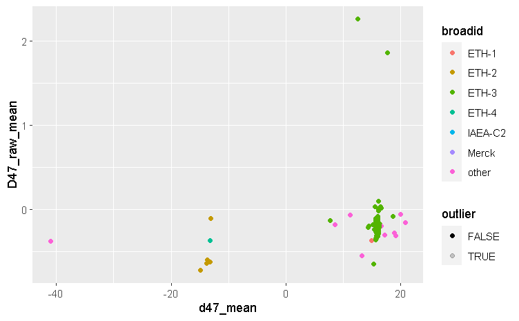

```r
tar_read(motu_temperature) |>
  measurement_filter() |>
  ggplot(aes(x = d47_mean, y = D47_raw_mean,
             colour = broadid, alpha = outlier,
             label = reason_for_outlier,
             fi = file_id, A = Analysis,
             s4 = s44_init, r4 = r44_init, p49 = param_49_mean, f = bg_fac)) +
  geom_point() +
  sam +
  ggnewscale::new_scale_colour() +
  stat_smooth(aes(group = preparation, colour = bg_fac),
              geom = "line", method = "lm", se = F, alpha = .3,
              data = # wr_raw_ss |> filter(!is.na(outlier_manual) & !outlier_manual)
                tar_read(motu_temperature) |>
                measurement_filter() |>
                filter(## Analysis %in% wr_ss$Analysis,
                  broadid %in% c("ETH-1", "ETH-2"), !outlier)
  ) #+
```

```r
   # coord_cartesian(xlim = c(-40, 22), ylim = c(-.7, .15))
```

the bottom line that’s sloped downward (lower ETH-1 than ETH-2) is preparation 447 it’s bg_fac should be changed from 0.95 to 0.91

# Critical P49

*** motu

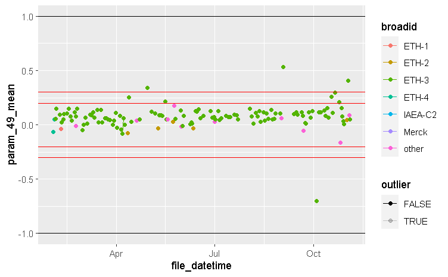

```r
  pl_p49 <- tar_read(motu_temperature) |>
    measurement_filter() |>
    ggplot(aes(x = file_datetime, y = param_49_mean, colour = broadid,
               alpha = outlier, label = reason_for_outlier,
               fi = file_id, a = Analysis)) +
     ## geom_vline(aes(xintercept = datetime,
     ##                n = Name,
     ##                p = `Samples (Name, material, #)`,
     ##                label = `Comments (issues, observations, maintenance):`),
     ##            data = tar_read(motu_log), alpha = .2, colour = "gray3") +
     ## geom_vline(aes(xintercept = Date,
     ##                n = Name,
     ##                p = `Problem (issues, observations):`,
     ##                a = Actions),
     ##            data = tar_read(motu_maintenance), alpha = .4) +
  geom_point() +
  geom_line(aes(group = broadid)) +
  scale_alpha_manual(values=c("TRUE" = 0.2, "FALSE" = 1)) +
  geom_hline(yintercept = tar_read(motu_temperature) |> distinct(p49_crit) |> pull(p49_crit) * c(-1, 1)) +
  geom_hline(yintercept = c(-.3, -.2, .2, .3), colour = "red") +
  coord_cartesian(ylim = c(-1, 1))
  pl_p49
```

# SDx4

** standard deviations of individual measurements

## d13C

```r
  motu_d13C_weak <- tar_read(motu_temperature) |>
    measurement_filter() |>
    ## tidylog::filter(!is.na(outlier_init), !outlier_init, !is.na(outlier_cycles), !outlier_cycles) |>
    tidylog::filter(!outlier) |>
    pull(d13C_PDB_sd) |>
    median()
```

[output not shown]

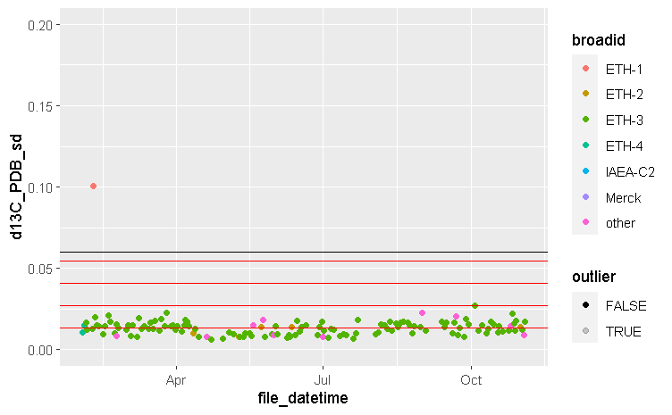

```r
  tar_read(motu_temperature) |>
    measurement_filter() |>
    ggplot(aes(x = file_datetime, y = d13C_PDB_sd, colour = broadid, alpha = outlier, label = reason_for_outlier,
               a = Analysis, fi = file_id, s4i = s44_init, r4i = r44_init, p49 = param_49_mean)) +
    geom_point() +
    scale_alpha_manual(values=c("TRUE" = 0.2, "FALSE" = 1)) +
    geom_hline(yintercept = tar_read(motu_temperature) |> distinct(sd_d13C) |> pull(sd_d13C)) +
    geom_hline(yintercept = motu_d13C_weak * c(1, 2, 3, 4), colour = "red") +
    coord_cartesian(ylim = c(0, .2))
```